# Reproducible Research: Peer Assessment 1

## Loading and preprocessing the data

In this section we can see setting workting directory and unzipping activity.zip and read csv with data.

```r
#install.packages('data.table'); install.packages('ggplot2'); install.packages('lattice')
require('data.table')
require('ggplot2')
require('lattice')
setwd("~/coursera/RepData_PeerAssessment1")
unzip('./activity.zip')
activity <- data.table(read.csv('./activity.csv'))

# preprocessing the data
activity$date <- as.Date(activity$date)
str(activity)
```

```
## Classes 'data.table' and 'data.frame':   17568 obs. of  3 variables:
##  $ steps   : int  NA NA NA NA NA NA NA NA NA NA ...
##  $ date    : Date, format: "2012-10-01" "2012-10-01" ...
##  $ interval: int  0 5 10 15 20 25 30 35 40 45 ...
##  - attr(*, ".internal.selfref")=<externalptr>
```

## What is mean total number of steps taken per day?

Taking the total number of steps aggregating by day and plotting the histogram.

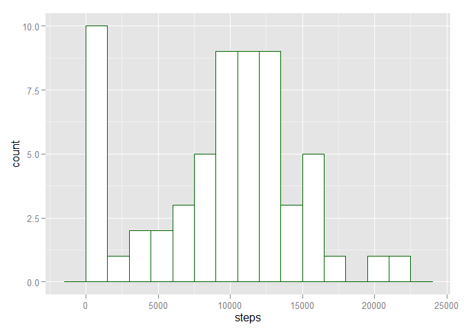

```r
total.steps <- activity[, list( steps = sum(steps, na.rm = TRUE)), by = date]
mean.steps   <- mean(total.steps$steps)
median.steps <- median(total.steps$steps)

m <- ggplot(total.steps, aes(x=steps))
m + geom_histogram(colour = "darkgreen", fill = "white", binwidth=1500)
```

Mean number of steps is 9354.23 and the median is 10395.

## What is the average daily activity pattern?

Performing the mean of each interval and plotting the results:

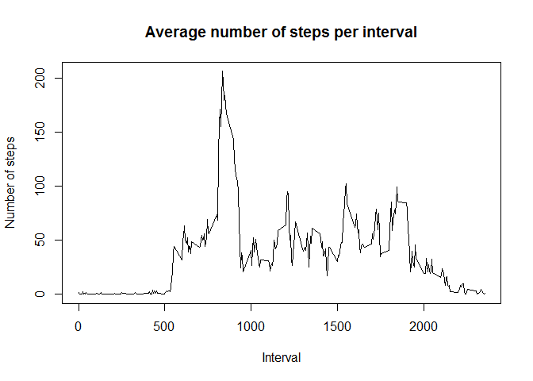

```r
interval.steps <- activity[ , list( mean = mean(steps,na.rm=TRUE) ), by = interval]

plot(interval.steps$interval, interval.steps$mean, type="l",
     xlab="Interval", ylab="Number of steps", main="Average number of steps per interval")
```

```r
max_interval <- interval.steps[which.max(interval.steps$mean ), ]$interval
```

The 5-minutes interval that contains maximum number of steps is 835

## Imputing missing values

1. Calculate and report the total number of missing values in the dataset (i.e. the total number of rows with NAs)

```r
sum(!complete.cases(activity))
```

```
## [1] 2304
```

2. Devise a strategy for filling in all of the missing values in the dataset. The strategy does not need to be sophisticated. For example, I choose to take the average for its interval.
3. Create a new data set with missing data filled in.

```r
activity.imputed <- copy(activity)
activity <- activity[ , mean.steps.interval := list(mean(steps,na.rm=TRUE)) , by = interval]
activity.imputed$steps <- as.numeric(activity.imputed$steps)
activity.imputed[is.na(activity.imputed$steps), ]$steps <- activity[is.na(activity$steps), ]$mean.steps.interval

str(activity.imputed)
```

```
## Classes 'data.table' and 'data.frame':   17568 obs. of  3 variables:
##  $ steps   : num  1.717 0.3396 0.1321 0.1509 0.0755 ...
##  $ date    : Date, format: "2012-10-01" "2012-10-01" ...
##  $ interval: int  0 5 10 15 20 25 30 35 40 45 ...
##  - attr(*, ".internal.selfref")=<externalptr>
```

Let’s repeat the same code as before but with our new table with imputed data.

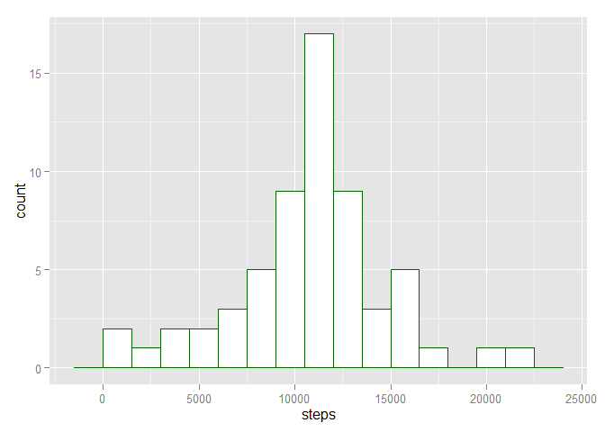

```r
total.steps <- activity.imputed[, list( steps = sum(steps, na.rm = TRUE)), by = date]
mean.steps   <- mean(total.steps$steps)
median.steps <- median(total.steps$steps)

m <- ggplot(total.steps, aes(x=steps))
m + geom_histogram(colour = "darkgreen", fill = "white", binwidth=1500)
```

The impact is that histogram seems to be more gaussian.

## Are there differences in activity patterns between weekdays and weekends?

1. Create a new factor variable in the dataset with two levels - “weekday” and “weekend” indicating whether a given date is a weekday or weekend day.
2. Plot that shows the difference between steps by interval and weekdays / weekend.

```r
Sys.setlocale("LC_TIME", "English")
```

```
## [1] "English_United States.1252"
```

```r
weekdays <- c("Monday", "Tuesday", "Wednesday", "Thursday", "Friday")
activity.imputed[ , day := as.factor(ifelse(is.element(weekdays(date),weekdays), "Weekday", "Weekend"))]
```

```
##            steps       date interval     day
##     1: 1.7169811 2012-10-01        0 Weekday
##     2: 0.3396226 2012-10-01        5 Weekday
##     3: 0.1320755 2012-10-01       10 Weekday
##     4: 0.1509434 2012-10-01       15 Weekday
##     5: 0.0754717 2012-10-01       20 Weekday
##    ---
## 17564: 4.6981132 2012-11-30     2335 Weekday
## 17565: 3.3018868 2012-11-30     2340 Weekday
## 17566: 0.6415094 2012-11-30     2345 Weekday
## 17567: 0.2264151 2012-11-30     2350 Weekday
## 17568: 1.0754717 2012-11-30     2355 Weekday
```

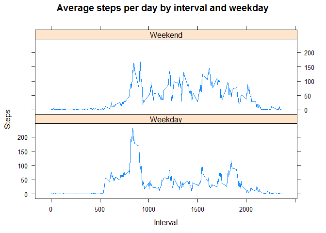

```r
steps_weeks <- activity.imputed[ ,  list( steps = mean(steps) ) , by = c('interval','day')]

xyplot(steps_weeks$steps ~ steps_weeks$interval| steps_weeks$day,
       main="Average steps per day by interval and weekday",
       xlab="Interval", ylab="Steps",
       layout=c(1,2), type="l")
```